# MICB425 Portfolio - Microbial Ecological Genomics: From Genomes to Biomes, Spring 2018

Albert Chang (26234147)

version April 07, 2018

# Module 01

Reserve the first level headings (#) for the start of a new Module. This will help to organize your portfolio in an intuitive fashion.  
**Note: Please edit this template to your heart’s content. This is meant to be the armature upon which you build your individual portfolio. You do not need to keep this instructive text in your final portfolio, although you do need to keep module and assignment names so we can identify what is what.**

## Module 01 portfolio check

The first of your second level headers (##) is to be used for the portfolio content checks. The Module 01 portfolio check has been built for you directly into this template, but will also be available as a stand-alone markdown document available on the MICB425 GitHub so that you know what is required in each module section in your portfolio. The completion status and comments will be filled in by the instructors during portfolio checks when your current portfolios are pulled from GitHub.

- Installation check
  - Completion status:
  - Comments:
- Portfolio repo setup
  - Completion status:
  - Comments:
- RMarkdown Pretty PDF Challenge
  - Completion status:
  - Comments:
- Evidence worksheet_01
  - Completion status:
  - Comments:
- Evidence worksheet_02
  - Completion status:
  - Comments:
- Evidence worksheet_03
  - Completion status:
  - Comments:
- Problem Set_01
  - Completion status:
  - Comments:
- Problem Set_02
  - Completion status:
  - Comments:
- Writing assessment_01
  - Completion status:
  - Comments:
- Additional Readings
  - Completion status:
  - Comments

## Data science Friday

The remaining second level headers (##) are for separating data science Friday, regular course, and project content. In this module, you will only need to include data science Friday and regular course content; projects will come later in the course.

### Installation check

Third level headers (###) should be used for links to assignments, evidence worksheets, problem sets, and readings, as seen here.

Use this space to include your installation screenshots.  
**Sent via e-mail**

### Portfolio repo setup

Detail the code you used to create, initialize, and push your portfolio repo to GitHub. This will be helpful as you will need to repeat many of these steps to update your porfolio throughout the course.

### RMarkdown pretty PDF challenge

**Please see Assignment_3.Rmd in DS_Friday folder.**

## Origins and Earth Systems

### Evidence worksheet 01

The template for the first Evidence Worksheet has been included here. The first thing for any assignment should link(s) to any relevant literature (which should be included as full citations in a module references section below).

You can copy-paste in the answers you recorded when working through the evidence worksheet into this portfolio template.

As you include Evidence worksheets and Problem sets in the future, ensure that you delineate Questions/Learning Objectives/etc. by using headers that are 4th level and greater. This will still create header markings when you render (knit) the document, but will exclude these levels from the Table of Contents. That’s a good thing. You don’t want to clutter the Table of Contents too much.

[Whitman *et al* 1998](https://www.ncbi.nlm.nih.gov/pmc/articles/PMC33863/)

#### Learning objectives

Describe the numerical abundance of microbial life in relation to ecology and biogeochemistry of Earth systems.

#### General questions

- What were the main questions being asked?
  - what is the number of prokaryotes on Earth
  - What is the range of prokaryotes present in specific parts of the Earth  
    (none of these questions were directly stated in the paper)
- What were the primary methodological approaches used?
  - No methods were described in the paper
  - Literature search/survey was done in order to obtain numbers for making estimates of the environments
  - Number calculated (of hypothetical sample) was extrapolated to estimate the number of prokaryotes present
- Summarize the main results or findings.
  - Cellular production rate is the highest in the open ocean
  - Prokaryotes contribute to approx. 60-100% of the total C found in plants (make up big portion of total C on Earth)
  - Subsurface = major habitat for prokaryotes (greatest in terms of number of prokaryotes present than that found in other parts of the biosphere)
  - Data not completely accurate since mostly estimated by extrapolation (may need to be revised)
  - Turnover time is fastest in domestic mammals (rapidly growing population, although it’s the least in terms of population size)
  - Cellular productivity of subsurface prokaryotes comparable to that of domestic animals
- Do new questions arise from the results?
  - Yes. The paper estimated the number of prokaryotes. How does the number of bacteria compare to that of archaea?
  - How does climate change affect prokaryote abundance? (Paper was published in 1998; if done again today, what would the results be and how would they compare?)
- Were there any specific challenges or advantages in understanding the paper (*e.g.* did the authors provide sufficient background information to understand experimental logic, were methods explained adequately, were any specific assumptions made, were conclusions justified based on the evidence, were the figures or tables useful and easy to understand)?
  - Not much background information nor description of methods were discussed in the paper
  - Did literature survey so each method will possibly have diferences (variability of results), as well as different uncertainties (error rate). Data will vary across reported results.
  - Didn’t really state purpose of the paper, particularly in the abstract; can make purpose more explicit so that it is easier to tie it to the bigger picture and help the reader understand the importance of the study

### Problem set 01

#### Learning objectives:

Describe the numerical abundance of microbial life in relation to the ecology and biogeochemistry of Earth systems.

### Evidence Worksheet_02 “Life and the Evolution of Earth’s Atmosphere”

#### Learning objectives:

Comment on the emergence of microbial life and the evolution of Earth systems

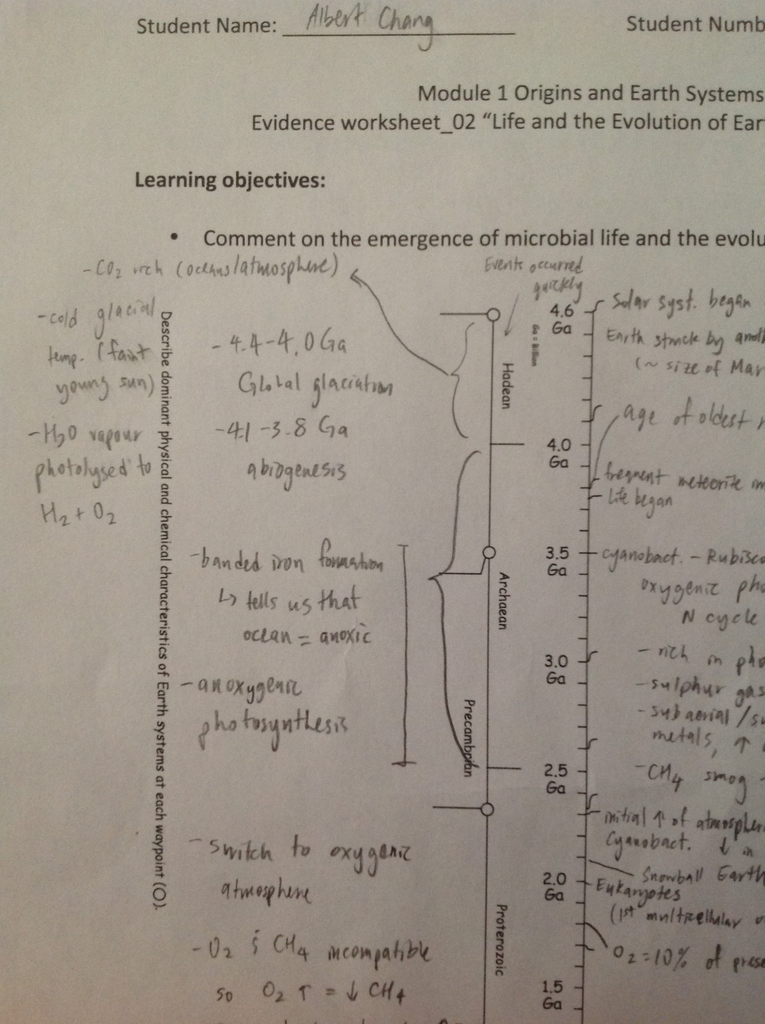

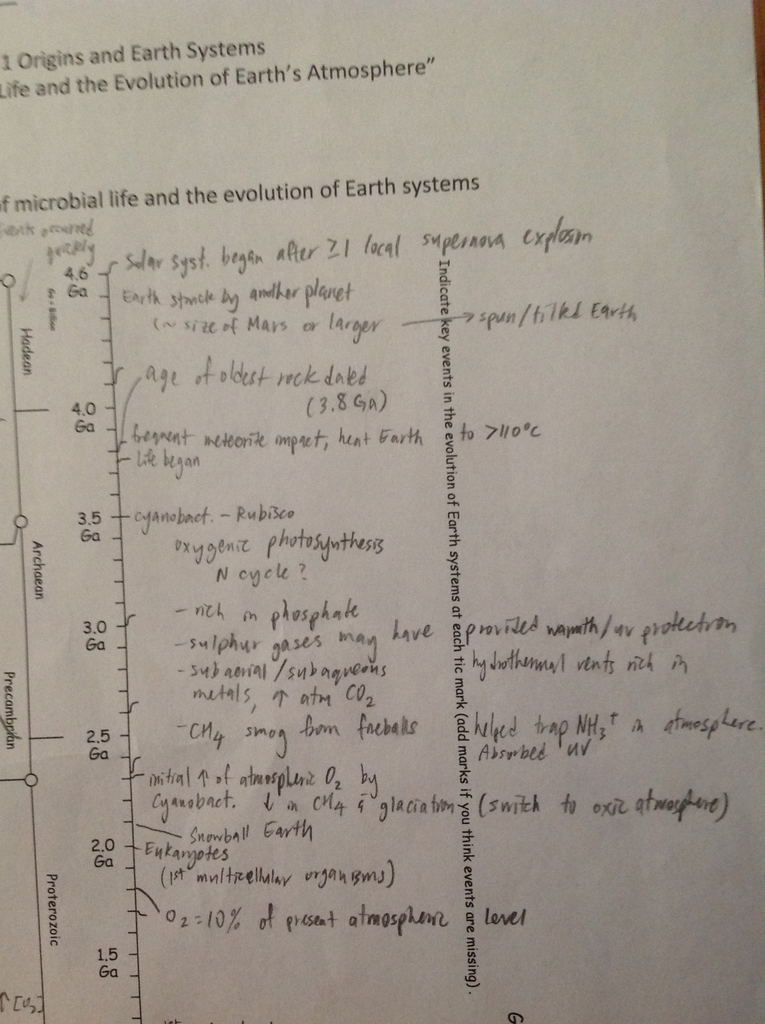

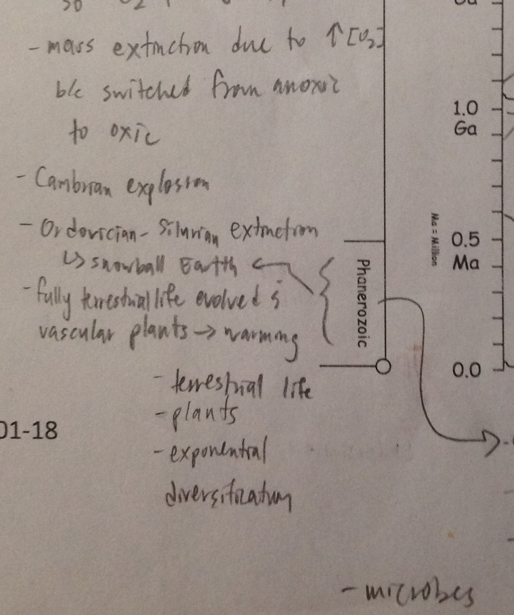

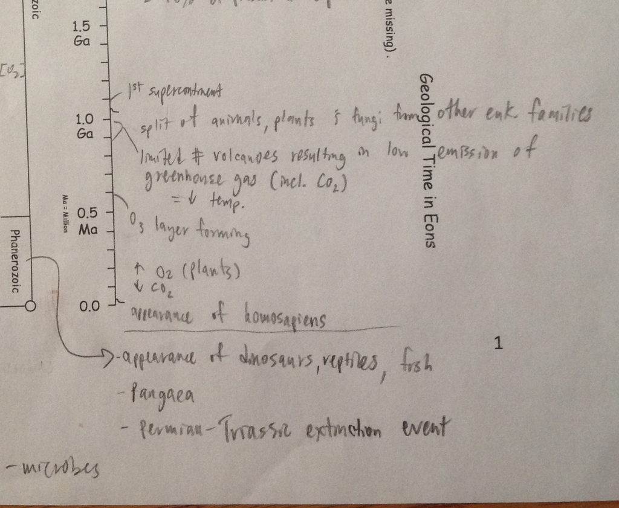

### Problem set_02 “Microbial Engines”

#### Learning objectives:

Discuss the role of microbial diversity and formation of coupled metabolism in driving global biogeochemical cycles.

#### Specific Questions:

- What are the primary geophysical and biogeochemical processes that create and sustain conditions for life on Earth? How do abiotic versus biotic processes vary with respect to matter and energy transformation and how are they interconnected?
  - geochemical cycles:
    - tectonics & atmospheric photochemical processes
      - supply substrates and remove products
    - allow elements and molecules to interact and form/break bonds in a cyclical manner
    - Most H<sub>2</sub> in mantle escape -> most geochemical reactions based on acid/base reactions (transfer of H<sup>+</sup> without e<sup>-</sup>)
    - volcanism and rock weathering resupply C, S, P
  - biochemical cycles: redox reactions
    - transfer e<sup>-</sup> and H<sup>+</sup> from limited set of elements
    - microbially catalyzed, thermodynamically constrained redox reactions (coupled half-cells)
- Why is Earth’s redox state considered an emergent property?
  - abiotic (acid/base) and biotic (redox) reactions altered surface redox state of the planet. Microbes took advantage of Earth’s acid/base redox energy.  
    –> The evolution of the processes created the redox condition of oceans and atmosphere
  - E.g. thermodynamic equilibrium would lead to eventual depeletion of substrates essential for life -> biological oxidation of Earth driven by photosynthesis by microbes (= energy transduction process not directly dependent on preformed bond energy)
- How do reversible electron transfer reactions give rise to element and nutrient cycles at different ecological scales? What strategies do microbes use to overcome thermodynamic barriers to reversible electron flow?
  - forward and reverse reactions required to maintain cycle
    - E.g. Methanogenic Archaea: CO<sub>2</sub> + H<sub>2</sub> -> CH<sub>4</sub>
      - If H<sub>2</sub> is low, then the reverse reaction becomes thermodynamically favourable and is done by another Archaea using the methanogic machinery in reverse.
  - sunlight replenishes energy that is lost
  - cooperation between deifferent species to overcome thermodynamic barriers
- Using information provided in the text, describe how the nitrogen cycle partitions between different redox ‘niches’ and microbial groups. Is there a relationship between the nitrogen cycle and climate change?
  - nitrogen fixation = the only biological process that makes N<sub>2</sub> accessible for sysnthesis of proteins/nucleic acids (N<sub>2</sub> -> NH<sub>4</sub><sup>+</sup>) -> biologically irreversible reaction catalyzed by nitrogenase (conserved enzyme), which is inhibited by O<sub>2</sub>
  - In presence of O<sub>2</sub>, NH<sub>4</sub><sup>+</sup> is oxidzied to NO<sub>2</sub><sup>-</sup> to NO<sub>3</sub><sup>-</sup>, all using a specific group of Bacteria or Archaea at each step. This also reduces CO<sub>2</sub> to organic C at the same time.
  - In the absence of O<sub>2</sub>, another set of microbes use NO<sub>2</sub><sup>-</sup> and NO<sub>3</sub><sup>-</sup> as electron acceptors in anaerobic oxidation of organic C and also forms N<sub>2</sub> (repeating the N cycle)
  - The N cycle is spatially separated, but forms interdependent e<sup>-</sup> pool influenced by photosynthetic production of O<sup>2</sup> and available organic matter
  - N<sub>2</sub>O is a greenhouse gas and can contribute to global warming. Also, micrboes in the N cycle convert organic C to CO<sub>2</sub>, which may impact the C cycle and climate change.
- What is the relationship between microbial diversity and metabolic diversity and how does this relate to the discovery of new protein families from microbial community genomes?
  - essential pathways: are conserved
  - but as microbial diversity increases, the number of new proteins discovered increases (new number of proteins increase linearly with number of new genomes sequenced)
- On what basis do the authors consider microbes the guardians of metabolism?
  - vertical and horizontal gene transfer allows the transfer and spread of genes needed for metabolic pathways. As such, the extinction of individual taxonomic units would not result in the extinction of core machines of the pathway.
  - machines, unlike microbes, can’t cycle waste back as substrate

### Evidence worksheet_03 “The Anthropocene”

#### Learning objectives:

Evaluate human impacts on the ecology and biogeochemistry of Earth systems.

#### General Questions:

- What were the main questions being asked?
  - Have humans changed the Earth system so much that the geological deposits are distinct from the Holocene & earlier epochs?
  - If so, when did this stratigraphic signal become recognizable worldwide?
- What were the primary methodological approaches used?
  - There was no method, but they reviewed data from previously published papers
  - They analyzed the published data to summarize the effects humans have on the environment and also to draw a timeline of events
  - Used stratigraphic record to compare to previous epochs
- Summarize the main results or findings.
  - Anthropocene: period marked by humans that changed Earth’s history (occurred recently)
  - invent of widespread and persistent materials; rapid production of those material leaves identifiable fossil and geochemical records (e.g. aluminum, plastics)
  - modification of sedimentary processes
    - transformed > 50% of Earth’s land for: landfills, urban structures, mining, cultivation, etc.
    - rising sea levels, eutrophication, coral bleaching, etc.
  - N and P in soils doubled due to increased fertilizer use
  - reactive N amount increased by 120% relative to Holocene baseline
  - Sea-level rise
  - Changes in climate and environment exceed Late Holocene changes
  - Radiogenic signatures and radionuclides in sediments/ice
    - excess <sup>14</sup>C (suggested as potential marker for start of Anthropocene)
    - <sup>239+240</sup>Pu fallout from nuclear weapons testing
  - CO<sub>2</sub> above 400ppm
- Do new questions arise from the results?
  - What are current innovations/strategies employed to slow down/solve the problems?
  - Although the authors listed various changes caused by humans, how would the authors officially define the start of Anthropocene? What is the boundary?
  - What other purposes are there to label this era as Anthropocene other than for historic purposes?
- Were there any specific challenges or advantages in understanding the paper (e.g. did the authors provide sufficient background information to understand experimental logic, were methods explained adequately, were any specific assumptions made, were conclusions justified based on the evidence, were the figures or tables useful and easy to understand)?
  - the author provided sufficient background information and data to reinforce their points
  - There were many figures, but they only referred to them briefly or not much at all during the discussion. So it felt like the figures were stand alones (although they are related to the text).
  - The figures had good descriptions and were easy to understand.

### Module_1 essay

Human beings are innovative creatures that have engineered many machines for technological advancement and manipulation of the environment, be it for better or for worse. That being said, are humans actually at the helm of Spaceship Earth, or are we only capable of living in the presence of a microbial world? We have utilized microbes to our advantage in innumerable processes, ranging from legume cropping in agriculture to fermentation in alcohol production, as well as denitrification in sewage treatment. As a matter of fact, humans have been relying on microbes prior to our acknowledgement of their existence. Microbes have been present on Mother Earth long before the existence of Homo sapiens and have established the distinctive, phenotypic features of Earth’s atmosphere suitable for human life. In addition, microbes are an essential part of Earth’s biogeochemical cycles, which are required to sustain the lives of the many other organisms which benefit the human species. Thus, humans live in a microbial world and would not be able to survive otherwise without the metabolic processes provided by microbes. Microbes, on the other hand, would easily thrive in a human-less world.

The human race as a whole is dependent on microbial activity for survival on Earth. First, microbes have established the current phenotypic atmosphere of Earth, allowing human existence. The atmosphere of the early Earth was anoxic and had a completely different composition than the atmosphere we have today (4). Abiotic and biotic factors such as volcanic eruptions and methane-producing microbes contributed to an atmosphere rich in carbon dioxide and methane (2). However, 2.3 Gyr ago, there was an initial rise in oxygen largely due to oxygenic photosynthesis performed by cyanobacteria (4). Although the rise in oxygen concentration led to a mass extinction known as the Great Oxygenation Event, the oxic atmosphere allowed the evolution of many aerobic organisms and brought about the species which would eventually be known as Homo sapiens (3).

In addition to establishing an atmosphere suitable for humans, microbes were capable of taking advantage of the abiotic geochemical reactions produced by Earth and have co-evolved to form biogeochemical cycles (2). These biogeochemical cycles are essential for the production of major elements required for building biological macromolecules such as proteins, lipids and nucleic acids and thus, are crucial for sustaining human life (2). Biogeochemical cycles are largely dependent on reduction-oxidation (redox) reactions mediated by microbes. These important cycles create fluxes of major essential elements such as hydrogen (H), carbon (C), nitrogen (N), oxygen (O) and sulfur (S) that are required for the synthesis of all biological macromolecules and ultimately, human survival (2). An example of a major biogeochemical cycle is the nitrogen cycle. The N cycle is formed by microbes and is essential for providing living organisms access to nitrogen, needed for the synthesis nucleic acid and proteins (1). Although approximately 78% of Earth’s atmosphere is composed of molecular nitrogen (N2), atmospheric nitrogen is inert and not readily available for human use (5). Nitrogen fixation is the only biological process currently available which allows the conversion of N2 to ammonium (NH4+), providing accessible nitrogen to humans, animals and non-nitrogen fixing plants altogether (2). Certain microbes, such as cyanobacteria, express nitrogenases and can catalyze the irreversible reaction to fix nitrogen (5). Following nitrogen fixation, nitrification and denitrification by certain microbes occur to convert the available nitrogen back into N2 to maintain the metabolic cycle and a balance between atmospheric nitrogen and available nitrogen (2). With the rapid growth of the human population, food becomes scarce and methods for increasing provisions are needed. Taking advantage of the endosymbiotic nitrogen-fixing microbes found in legumes, humans have developed sustainable approaches for agriculture, such as legume cropping in lieu of synthetic fertilizers, in order to provide accessible nitrogen to crops (1). Thus, microbes have played and continue to play an integral role in the storybook of human survival.

In conclusion, microbes have played a vital part in providing the appropriate environment required for human existence and continue to play an integral part for human life on Earth. Not only have microbes lived long before the appearance of Homo sapiens, microbes have evolved and adapted to the harsh geological environment-be it by natural causes or by human influence-and have changed the phenotype of Earth’s atmosphere to establish a habitable place for humans today. Lastly, microbial metabolic pathways are necessary to maintain biogeochemical cycles. This allows microbes to catalyze thermodynamically constrained redox reactions of the cycles, allowing their own survival and that of other living organisms.

### Module 01 references

Utilize this space to include a bibliography of any literature you want associated with this module. We recommend keeping this as the final header under each module.

- Whitman WB, Coleman DC, and Wiebe WJ. 1998. Prokaryotes: The unseen majority. Proc Natl Acad Sci USA. 95(12):6578â“6583. [PMC33863](https://www.ncbi.nlm.nih.gov/pmc/articles/PMC33863/)
- Achenbach, J. (2012). Spaceship Earth: A new view of environmentalism. Washington Post (January 2, 2012).
- Falkowski, P. G., Fenchel, T., & Delong, E. F. (2008). The microbial engines that drive Earth’s biogeochemical cycles. science, 320(5879), 1034-1039. [link](http://science.sciencemag.org/content/320/5879/1034)
- Canfield, D. E., Glazer, A. N., & Falkowski, P. G. (2010). The evolution and future of Earth’s nitrogen cycle. science, 330(6001), 192-196. [link](http://science.sciencemag.org/content/330/6001/192)
- Kasting, J. F., & Siefert, J. L. (2002). Life and the evolution of Earth’s atmosphere. Science, 296(5570), 1066-1068. [link](http://science.sciencemag.org/content/296/5570/1066)
- Nisbet, E. G., & Sleep, N. H. (2001). The habitat and nature of early life. Nature, 409(6823), 1083. [link](https://www.nature.com/articles/35059210)
- Leopold, A. (2014). The land ethic. In The Ecological Design and Planning Reader (pp. 108-121). Island Press, Washington, DC. [link](https://link.springer.com/chapter/10.5822/978-1-61091-491-8_12)
- Falkowski, P., Scholes, R. J., Boyle, E. E. A., Canadell, J., Canfield, D., Elser, J., … & Mackenzie, F. T. (2000). The global carbon cycle: a test of our knowledge of earth as a system. science, 290(5490), 291-296. [link](http://science.sciencemag.org/content/290/5490/291)
- Kallmeyer, J., Pockalny, R., Adhikari, R. R., Smith, D. C., & D’Hondt, S. (2012). Global distribution of microbial abundance and biomass in subseafloor sediment. Proceedings of the National Academy of Sciences, 109(40), 16213-16216. [link](http://www.pnas.org/content/109/40/16213.short)
- Rockström, J., Steffen, W., Noone, K., Persson, Å., Chapin III, F. S., Lambin, E. F., … & Nykvist, B. (2009). A safe operating space for humanity. nature, 461(7263), 472. [link](https://www.nature.com/articles/461472a)
- Schrag, D. P. (2012). Geobiology of the Anthropocene. Fundamentals of geobiology, 425-436.[link](https://onlinelibrary.wiley.com/doi/10.1002/9781118280874.ch22)
- Waters, C. N., Zalasiewicz, J., Summerhayes, C., Barnosky, A. D., Poirier, C., Galuszka, A., … & Jeandel, C. (2016). The Anthropocene is functionally and stratigraphically distinct from the Holocene. Science, 351(6269), aad2622. [link](http://science.sciencemag.org/content/351/6269/aad2622)
- Zehnder, A. J. (1988). Biology of anaerobic microorganisms. John Wiley and Sons Inc.. [link](https://www.cabdirect.org/cabdirect/abstract/19911956781)

References for Essay:  
1. Canfield, DE, Glazer, AN, Falkowski, PG. 2010. The Evolution and Future of Earth’s Nitrogen Cycle. Science. 330:192-196. doi: 10.1126/science.1186120.  
2. Falkowski, PG, Fenchel, T, Delong, EF. 2008. The Microbial Engines That Drive Earth’s Biogeochemical Cycles. Science. 320:1034-1039. doi: 10.1126/science.1153213.  
3. Fischer, WW, Hemp, J, Valentine, JS. 2016. How did life survive Earth’s great oxygenation? Curr. Opin. Chem. Biol. 31:166-178. doi: 10.1016/j.cbpa.2016.03.013.  
4. Kasting, J, Siefert, J. 2003. Life and the evolution of Earth’s atmosphere (vol 296, pg 1066, 2002). Science. 299:1015-1015.  
5. Sleep, NH, Nisbet, EG. 2001. The habitat and nature of early life. Nature. 409:1083-1091. doi: 10.1038/35059210.

# Module 02

## Remapping the Body of the World

### Problem set_03 “Metagenomics: Genomic Analysis of Microbial Communities”

#### Learning objectives:

Specific emphasis should be placed on the process used to find the answer. Be as comprehensive as possible e.g. provide URLs for web sources, literature citations, etc.  
*(Reminders for how to format links, etc in RMarkdown are in the RMarkdown Cheat Sheets)*

#### Specific Questions:

- How many prokaryotic divisions have been described and how many have no cultured representatives (microbial dark matter)?
  - Solden et al. (2016). “The Bright Side of Microbial Dark Matter: Lessons Learned from the Uncultivated Majority”. -> 89 Bacterial and 20 Archaeal phyla recogized by small rRNA subunits
    - only 0.1 - 1% of microbes in environment have been cultured
  - Youssef et al. (2015). “Assessing the Global Phylum Level Diversity Within the Bacterial Domain: A Review”
    - 70 bacterial phyla with no cultured representatives (this number may be greater)
    - previously confined to pure cultures, found 12 bacterial phyla with cultured representatives: Actinobacteria, Bacteroidetes, Chlamydiae, Chlorobi, Chloroflexi, Cyanobacteria, Thermi (Deinococcus-Thermus), Firmicutes, Planctomycetes, Proteobacteria, Spirochaetes, Thermotogae
- How many metagenome sequencing projects are currently available in the public domain and what types of environments are they sourced from?
  - From EBI Metagenomics (Europe)
    - 1486 public projects
    - 86201 samples
    - soil, marine, grassland, fecal, rumens, agriculture, etc.
  - JGI (U.S.)
    - 36715 public projects
- What types of on-line resources are available for warehousing and/or analyzing environmental sequence information (provide names, URLS and applications)?
  - MEGAN (metagenome analyzer)
    - http://ab.inf.uni-tuebingen.de/software/megan5/download/welcome.html
    - analyze metagenomes and group using taxonomic analysis
  - IMG/M (Integrated Microbial Genomes)
    - http://img.jgi.doe.gov/cgi-bin/m/main.cgi
    - tool for analyzing publicly available genome/metagenome datasets
  - MG-RAST (metagenomics analysis server)
    - https://www.mg-rast.org/
  - Tag-based sequencing: SSU rRNA -> MOTHUR, QIIME
  - BLAST (NCBI)
- What is the difference between phylogenetic and functional gene anchors and how can they be used in metagenome analysis?
  - Phylogenetic anchors:
    - link other unknown genes within genome to a taxon
    - collection of genes can be placed into bins of discrete taxonomic groups
    - only one copy per cell; ensures no HGT, and genes only appear once in tree
    - Looks at size of bins for relative abundance of taxa
  - Functional anchors:
    - tells what the cell does
    - search for gene that codes for protin involved in the terminal steps of a pathway
    - can count abundance of phylogenetic anchor
- What is metagenomic sequence binning? What types of algorithmic approaches are used to produce sequence bins? What are some risks and opportunities associated with using sequence bins for metabolic reconstruction of uncultivated microorganisms?
  - binning: grouping reads or contigs and assigning them to operational taxonomic units (OTU)
    - Taxonomy dependent - classifies DNA fragments by comparing to reference database
    - Taxonomy independent - reference free binning by clustering similar features (e.g. GC content, etc.)
  - sequence composition based binning -> genomic signatures
    - Interpolated Markov Model (IMM)
  - abundance based binning
    - Expectation-Maximization (EM) algorithm -Hybrid binning
    - Lander-Waterman model Sedlar et al. (2016) “Bioinformatics strategies for taxonomy independent binning and visualization of sequence in shotgun metagenomics”
- Is there an alternative to metagenomic shotgun sequencing that can be used to access the metabolic potential of uncultivated microorganisms? What are some risks and opportunities associated with this alternative?
  - Douterelo et al. (2014). “Methodological approaches for studying the microbial ecology of drinking water distribution systems.”
  - Clone dependent shotgun library
    - Find functions of proteins from the gene of uncultivable microbes by cloning gene fragments into an expression host
    - Limitation: gene may not be compatible with the host
  - Pacific Bioscience
  - Nanopore
  - Metatranscriptomes
    - RT-qPCR: -high sensitivity, can run multiple samples + analyze different genes at once
      - quantitative representation of changes in gene expression due to different treaments/controls
      - Limitations:
        - RNA is highly unstable
        - DNA extracted needs to be pure
    - Functional Microarrays:
      - Overall assessment of gene expression within a microbial community
      - simultaneous evaluation of many mRNA (rapid)
      - Limitations:
        - liquid chromatography/2D gels for protein separation can be tedious
        - Must use LC-MS (Liquid chromatography-mass spectrometry) to characterize samples

### Evidence worksheet_04 “Bacterial Rhodopsin Gene Expression”

#### Learning objectives:

- Discuss the relationship between microbial community structure and metabolic diversity
- Evaluate common methods for studying the diversity of microbial communities
- Recognize basic design elements in metagenomic workflows

#### General Questions:

- What were the main questions being asked?
  - To describe and understand more about proteorhodopsins (PRs), photosystem genetics and biochemistry (foud that proteorhodopsin isn’t needed, but provides extra energy in form of ATP)
  - What is the physiological basis of light-activated growth stimulation and the function of the various PR photosystems?
  - Can we recover a functional PR-system in a metagenomic screening context?
  - Can a single genetic event (HGT/LGT operon) confer PR-system functionality?
- What were the primary methodological approaches used?
  - Created fosmid library (gene library) -> clone in E. coli -> Screen by colour change -> extract carotenoid gene
  - Sequenced to compreltion using Tn5-Seq
    - Use copy control and induced with arabinose
      - slight colour shift may have been hard to discern (so 3/12000 hits)
  - Proton-Pumping experiment and ATP measurements
  - HPLC Analysis of metabolites
- Summarize the main results or findings.
  - Only 6 genes are required to enable light-activated proton translocation and photophosphorylation
    - these 6 genes found in marine bacterial taxa
      - these are necessary and sufficient for complete synthesis and assembly of a fully functional PR photoprotein in E. coli
  - demonstrated that illumination of cells expressing a native marine bacterial PR photosystem generates a PMF that drives celluar ATP synthesis
  - a single genetic event can result in the acquisition of phototrophic capabilities in chemoorganotrophic microorganisms
- Do new questions arise from the results?
  - Paper mentioned that light stimulation/yield in Pelagibacter ubique in previous study had a negative result that may be due to the influence of various factors in seawater. Are there perhaps other reasons it didn’t work on P. ubique?
  - Why were only 3/12280 clone identified?
- Were there any specific challenges or advantages in understanding the paper (e.g. did the authors provide sufficient background information to understand experimental logic, were methods explained adequately, were any specific assumptions made, were conclusions justified based on the evidence, were the figures or tables useful and easy to understand)?
  - Sufficient background information was provided
  - The figures and figure font were a bit too small to read without having to zoom in 300%

### Module 02 references

Utilize this space to include a bibliography of any literature you want associated with this module. We recommend keeping this as the final header under each module.

- Madsen, E. L. (2005). Identifying microorganisms responsible for ecologically significant biogeochemical processes. Nature Reviews Microbiology, 3(5), 439. [link](https://www.nature.com/articles/nrmicro1151)
- Taupp, M., Mewis, K., & Hallam, S. J. (2011). The art and design of functional metagenomic screens. Current opinion in biotechnology, 22(3), 465-472. [link](https://www.sciencedirect.com/science/article/pii/S0958166911000371)
- Martinez, A., Bradley, A. S., Waldbauer, J. R., Summons, R. E., & DeLong, E. F. (2007). Proteorhodopsin photosystem gene expression enables photophosphorylation in a heterologous host. Proceedings of the National Academy of Sciences, 104(13), 5590-5595. [link](http://www.pnas.org/content/104/13/5590.short)
- Wooley, J. C., Godzik, A., & Friedberg, I. (2010). A primer on metagenomics. PLoS computational biology, 6(2), e1000667. [link](http://journals.plos.org/ploscompbiol/article?id=10.1371/journal.pcbi.1000667)

# Module 03

## Microbial Species Concepts

### Problem set_04 “Fine-scale phylogenetic architecture”"

#### Learning objectives:

- Gain experience estimating diversity within a hypothetical microbial community

#### Part 1: Description and enumeration

Obtain a collection of “microbial” cells from “seawater”. The cells were concentrated from different depth intervals by a marine microbiologist travelling along the Line-P transect in the northeast subarctic Pacific Ocean off the coast of Vancouver Island British Columbia.

Sort out and identify different microbial “species” based on shared properties or traits. Record your data in this Rmarkdown using the example data as a guide.

Once you have defined your binning criteria, separate the cells using the sampling bags provided. These operational taxonomic units (OTUs) will be considered separate “species”. This problem set is based on content available at [What is Biodiversity](http://cnx.org/content/m12179/latest/).

For example, load in the packages you will use.

```r
#To make tables
library(kableExtra)
library(knitr)
#To manipulate and plot data
library(tidyverse)
```

Then load in the data. You should use a similar format to record your community data.

```r
example_data1 = data.frame(
  number = c(1,2,3),
  name = c("lion", "tiger", "bear"),
  characteristics = c("brown cat", "striped cat", "not a cat"),
  occurences = c(2, 4, 1)
)
```

Finally, use these data to create a table.

```r
example_data1 %>%
  kable("html") %>%
  kable_styling(bootstrap_options = "striped", font_size = 10, full_width = F)
```

| number | name | characteristics | occurences |
| --- | --- | --- | --- |
| 1 | lion | brown cat | 2 |
| 2 | tiger | striped cat | 4 |
| 3 | bear | not a cat | 1 |

For your community:

- Construct a table listing each species, its distinguishing characteristics, the name you have given it, and the number of occurrences of the species in the collection.
- Ask yourself if your collection of microbial cells from seawater represents the actual diversity of microorganisms inhabiting waters along the Line-P transect. Were the majority of different species sampled or were many missed?

```r
candy_counts = read.table(file="Candy_community.csv", header=TRUE, sep=",", na.strings=c("NAN", "NA", "."))
candy_table = candy_counts %>% kable("html")

#The collection of microbial cells from seawater does not represent the actual diversity of microorganisms inhabtigin waters along the Line-P transect. Many were missed, especially if the abundance was low for those species in the first place.
```

[output not shown]